# SingleMoleculeFootprinting

## Analysis of single site

### Methylation extraction

Methylation values at the single molecule level can be extracted for the region of interest from aligned data using the `CallContextMethylation` function. Under the hood, the function performs the following operations:

- Identification of the methylation status for the Cytosines in the genomic context relevant for the experiment (Single enzyme, double enzyme, etc.). The type of the experiment is inferred based on which user-provided substring is found in the SampleName field of the QuasR pointer file:

| ExperimentType | substring | RelevanContext | Notes |
| --- | --- | --- | --- |
| Single enzyme SMF | _NO_ | DGCHN & NWCGW | Methylation info is reported separately for each context |
| Double enzyme SMF | _DE_ | GCH + HCG | Methylation information is aggregated across the contexts |
| No enzyme (endogenous mCpG only) | _SS_ | CG | - |

```r
MySample <- suppressMessages(readr::read_delim(Qinput, delim = "\t")[[2]])
Region_of_interest <- GRanges(seqnames = "chr6",
                              ranges = IRanges(start = 88106000,
                                               end = 88106500),
                              strand = "*")

Methylation <- CallContextMethylation(sampleSheet = Qinput,
                                      sample = MySample,
                                      genome = BSgenome.Mmusculus.UCSC.mm10,
                                      RegionOfInterest = Region_of_interest,
                                      coverage = 20,
                                      returnSM = TRUE,
                                      ConvRate.thr = NULL)
## Setting QuasR project
## all necessary alignment files found
## Calling methylation at all Cytosines
## Extracting single molecule matrix
## checking if RegionOfInterest contains information at all
## Discard immediately the cytosines not covered in any sample
## Subsetting Cytosines by permissive genomic context (GC, HCG)
## Collapsing strands
## 5334 reads found mapping to the - strand, collapsing to +
## 5334 reads found mapping to the - strand, collapsing to +
## Filtering Cs for coverage
## Detected experiment type: DE
## Subsetting Cytosines by strict genomic context (GCH, GCG, HCG) based on the detected experiment type: DE
## Merging matrixes
Methylation[[1]]
## GRanges object with 48 ranges and 3 metadata columns:
##        seqnames    ranges strand | NRF1pair_DE__Coverage NRF1pair_DE__MethRate
##           <Rle> <IRanges>  <Rle> |             <numeric>             <numeric>
##    [1]     chr6  88106098      + |                  5323              0.866992
##    [2]     chr6  88106113      + |                  5319              0.741117
##    [3]     chr6  88106115      + |                  5322              0.897595
##    [4]     chr6  88106119      + |                  5322              0.838407
##    [5]     chr6  88106126      + |                  5321              0.543319
##    ...      ...       ...    ... .                   ...                   ...
##   [44]     chr6  88106435      + |                  5317              0.554072
##   [45]     chr6  88106445      + |                  5315              0.607526
##   [46]     chr6  88106456      + |                  5312              0.679593
##   [47]     chr6  88106493      + |                  5305              0.720641
##   [48]     chr6  88106496      + |                  5302              0.809129
##        GenomicContext
##           <character>
##    [1]            GCH
##    [2]            GCG
##    [3]            GCG
##    [4]            GCH
##    [5]            HCG
##    ...            ...
##   [44]            GCH
##   [45]            GCH
##   [46]            GCH
##   [47]            GCH
##   [48]            GCH
##   -------
##   seqinfo: 1 sequence from an unspecified genome; no seqlengths
Methylation[[2]]$NRF1pair_DE_[1:10, 1:10]
## 10 x 10 sparse Matrix of class "dgCMatrix"
##   [[ suppressing 10 column names '88106098', '88106113', '88106115' ... ]]
##
## M00758:819:000000000-CB7NB:1:1101:10081:9865  2 1 2 2 2 1 2 2 2 2
## M00758:819:000000000-CB7NB:1:1101:10119:12887 1 1 1 1 1 2 2 2 2 2
## M00758:819:000000000-CB7NB:1:1101:10172:5248  1 2 2 2 2 1 2 2 2 2
## M00758:819:000000000-CB7NB:1:1101:10214:24193 1 1 1 1 1 1 1 2 1 2
## M00758:819:000000000-CB7NB:1:1101:10219:24481 2 2 2 2 1 1 1 2 1 2
## M00758:819:000000000-CB7NB:1:1101:10408:27375 2 2 2 2 1 1 1 2 1 2
## M00758:819:000000000-CB7NB:1:1101:10428:10873 2 1 2 2 2 1 2 2 2 2
## M00758:819:000000000-CB7NB:1:1101:10428:22900 2 2 2 2 2 1 2 2 2 2
## M00758:819:000000000-CB7NB:1:1101:10453:11606 2 2 1 2 1 2 1 2 2 2
## M00758:819:000000000-CB7NB:1:1101:10489:13730 2 2 2 2 2 1 2 2 2 2
```

The following chunk has the sole scope of down-sampling reads to make the vignette lighter. The user should skip this.

```r
n = 1000
readsSubset <- sample(seq(nrow(Methylation[[2]]$NRF1pair_DE_)), n)
Methylation[[2]]$NRF1pair_DE_ <- Methylation[[2]]$NRF1pair_DE_[readsSubset,]
```

### Plotting single sites

Already at this stage it is possible to visually inspect results. To that end, we provide the function `PlotAvgSMF` to plot the average SMF signal, defined as 1 - **average methylation**, at a genomic locus of interest. Optionally, the user can pass a GRanges object of genomic coordinates for the transcription factor binding sites (**TFBSs**) of interest to include in the plot, we show an example of such an object.

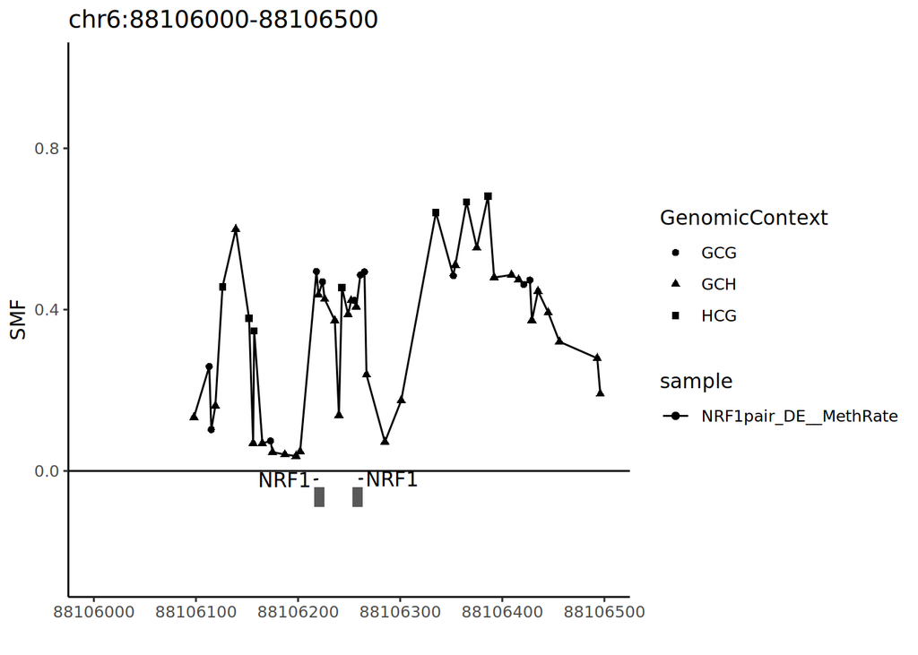

```r
TFBSs <- GenomicRanges::GRanges("chr6",
                               IRanges(c(88106216, 88106253),
                                       c(88106226, 88106263)),
                               strand = "-")
elementMetadata(TFBSs)$TF <- c("NRF1", "NRF1")
names(TFBSs) <- c(paste0("TFBS_", c(4305215, 4305216)))
TFBSs
## GRanges object with 2 ranges and 1 metadata column:
##                seqnames            ranges strand |          TF
##                   <Rle>         <IRanges>  <Rle> | <character>
##   TFBS_4305215     chr6 88106216-88106226      - |        NRF1
##   TFBS_4305216     chr6 88106253-88106263      - |        NRF1
##   -------
##   seqinfo: 1 sequence from an unspecified genome; no seqlengths

PlotAvgSMF(MethGR = Methylation[[1]],
           RegionOfInterest = Region_of_interest,
           ShowContext = TRUE,
           TFBSs = TFBSs)
## No sorted reads passed...plotting counts from all reads
```

Furthermore, the function `PlotSM` can be used to plot the single molecule SMF information at a given site.

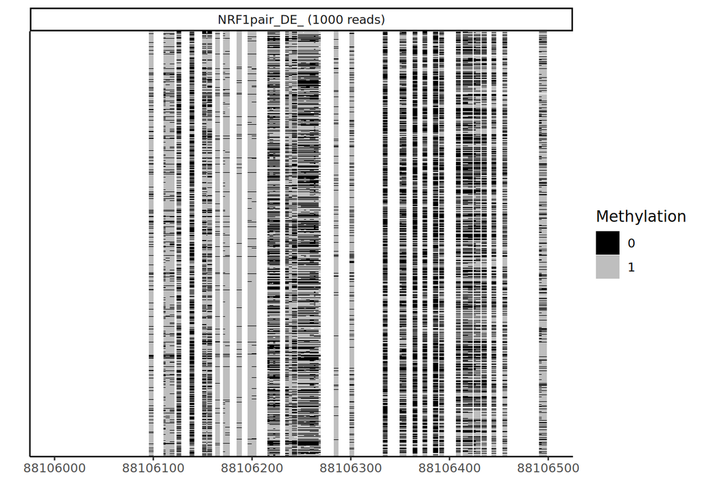

```r
PlotSM(MethSM = Methylation[[2]],
       sorting.strategy = "None",
       RegionOfInterest = Region_of_interest)
## No sorting passed or specified, will plot unsorted reads
```

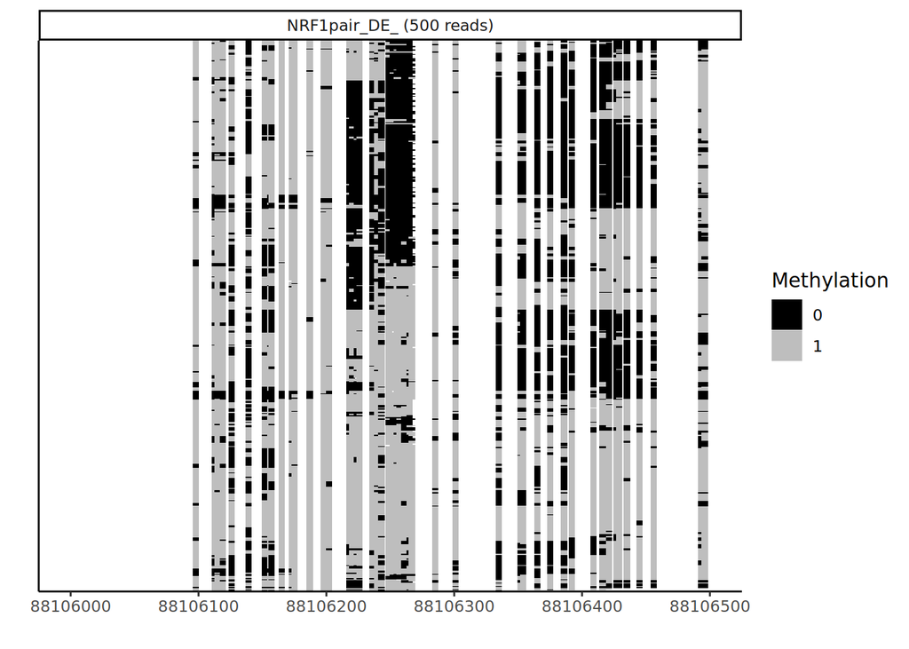

```r
PlotSM(MethSM = Methylation[[2]],
       RegionOfInterest = Region_of_interest,
       sorting.strategy = "hierarchical.clustering",
       SortedReads = NULL)
## Perfoming hierarchical clustering on single molecules before plotting
```

### Single Molecule Sorting

Ultimately though, we want to classify reads based on their patterns of molecular occupancy. To that end we provide the functions `SortReadsBySingleTF` and `SortReadsByTFCluster` to classify reads based either on the occupancy patterns of one or multiple transcription factors.

Under the hood, the classification is based on the definition of $n+2$ bins (with $n$ being the number of TFs). The $n$ bins are each centered around one of the TFBSs of interest, while the 2 extra bins are located upstream and downstream of the two outmost TFBSs.

For `SortReadsBySingleTF`, the coordinates of the bins relative to the center of the TFBS are [-35;-25], [-15;+15], [+25,+35]. Instead, the function `SortReadsByTFCluster` draws a bin with coordinates [-7;+7] around the center of each TFBS, a bin with coordinates [-35;-25] relative to center of the most upstream TFBS and a bin with coordinates [+25,+35] relative to the center of the most downstream TFBS. The user can also employ custom coordinates by specifying them explicitly using the function `SortReads`.

For each read, the binary methylation status of the cytosines contained in each bin is averaged to either a 0 or a 1 such that each read is eventually represented as sequence of $n+2$ binary digits, for a total of $2^{(n+2)}$ possible sequences.

Here, we show a usage case for the `SortReadsByTFCluster` function, as we have already identified the double binding of NRF1 at the genomic site under scrutiny. Usage and exploration of the output is identical for the other function, except for the the format of the *TFBSs* argument which should consist of a GRanges object of length 1 for `SortReadsBySingleTF` and of length $>$ 1 for `SortReadsByTFCluster`.

```r
SortedReads_TFCluster <- SortReadsByTFCluster(MethSM = Methylation[[2]], coverage = 30, bins = list(c(-35,-25), c(-7,7), c(25,35)), TFBS_cluster = TFBSs)
## Sorting TFBSs by genomic coordinates
## Designing sorting bins
## Collecting summarized methylation for bins
## Subsetting those reads that cover all bins
## Summarizing reads into patterns
## Splitting reads by pattern
```

```
## Number of retrieved states: 13
## States population:
## 0000 0001 0011 0101 0111 1000 1001 1010 1011 1100 1101 1110 1111
##    2    5    7    8   16   18  294    7  148   17   97   28  353
```

N.b. non-populated states are not returned.

The output of each of these sorting functions can be passed directly as the `SortedReads` argument of the `PlotSM` function.

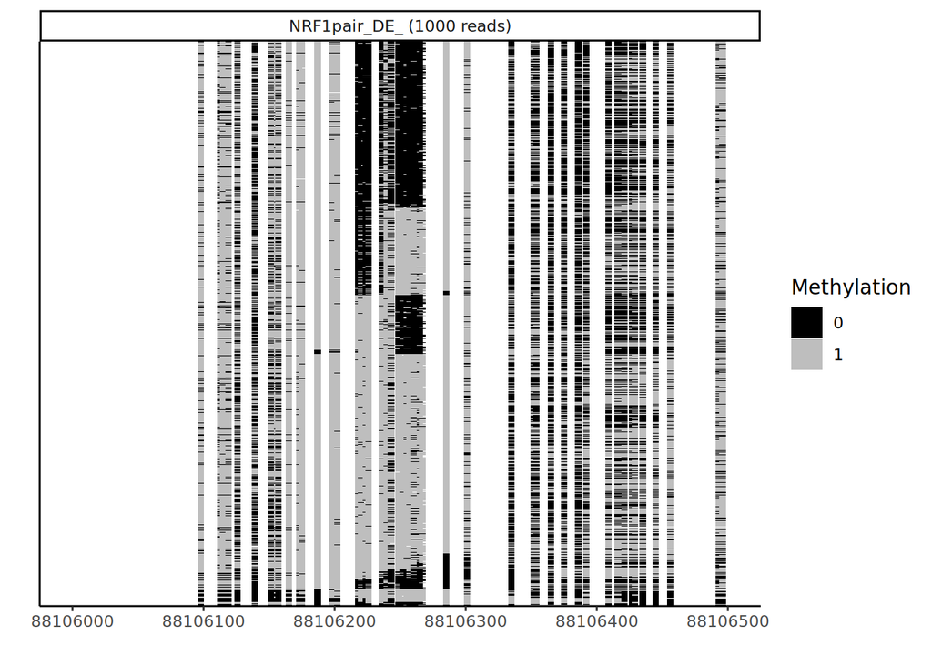

```r
PlotSM(MethSM = Methylation[[2]], RegionOfInterest = Region_of_interest, sorting.strategy = "classical", SortedReads = SortedReads_TFCluster)
## Arranging reads according to classical sorting.strategy
## Inferring sorting was performed by TF pair
```

N.b. despite sorting reads by a TF cluster is in principle possible with clusters of any size, as of now the `PlotSM` function can only deal with TF pairs.

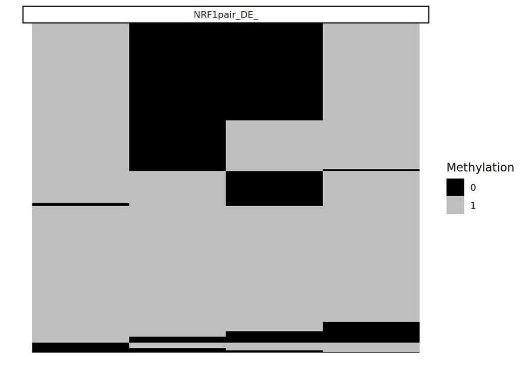

```r
StateQuantificationPlot(SortedReads = SortedReads_TFCluster)
## Inferring sorting was performed by TF pair
```

Finally, we provide the wrapper function `PlotSingleSiteSMF` to plot at once the three kinds of information detailed above and to export results as a pdf.

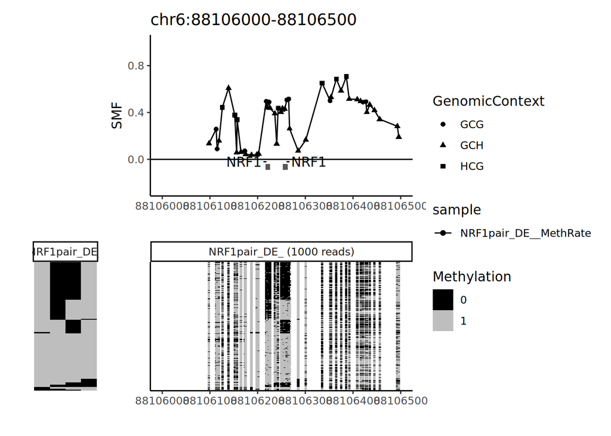

```r
PlotSingleSiteSMF(Methylation = Methylation,
                  RegionOfInterest = Region_of_interest,
                  ShowContext = TRUE,
                  sorting.strategy = "classical",
                  SortedReads = SortedReads_TFCluster,
                  TFBSs = TFBSs)
## Producing average SMF plot
## Sorted reads passed along with SM matrix...plotting only counts relevant to sorting
## Producing Single Molecule stacks
## Arranging reads according to classical sorting.strategy
## Inferring sorting was performed by TF pair
## Producing state quantification plots
## Inferring sorting was performed by TF pair
## Combining plots
```